# Movement metrics and First impression

## Objective

Do movement characteristics predict observers’ first impression?

We first look at the three global metrics separately, to check that their relationships with FirstImpression are consistent. We then combine them into a single composite score and test it with a mixed model.

Spearman is used for all correlations because FirstImpression is a bounded sum of Likert items; it also captures monotonic relationships even if the link is not strictly linear.

```r
library(readr)
library(dplyr)
library(ggplot2)
library(tidyr)
library(lme4)
library(lmerTest)
library(performance)
library(rempsyc)
library(flextable)
```

```r
dir.create("../results/tables",  showWarnings = FALSE, recursive = TRUE)
dir.create("../results/figures", showWarnings = FALSE, recursive = TRUE)

source("../sources/questionnaire_analysis.R")
source("../sources/movement_statistics.R")
source("../sources/movement_first_impression.R")

data_imp          <- read_csv("../data/data_imp.csv", show_col_types = FALSE)
movement_features <- read_csv(
  "../data/all_participants_movement_features.csv",
  show_col_types = FALSE
)
```

## 1. Each metric against First impression

```r
cor_per_metric <- build_metric_impression_correlations_per_metric(
  data_imp, movement_features
)

write_csv(cor_per_metric,
          "../results/tables/metric_impression_correlations_per_metric.csv")

rempsyc::nice_table(
  cor_per_metric,
  title = c("Table 1",
            "Spearman correlations between each global movement metric and First impression"),
  note  = c("Stimulus-level correlations (n = 40 videos). The three metrics show very similar associations with FirstImpression, which justifies combining them into a single composite score below.",
            "* p < .05, ** p < .01, *** p < .001")
)
```

| Table 1 Spearman correlations between each global movement metric and First impression Metric | Table 1 Spearman correlations between each global movement metric and First impression n | Table 1 Spearman correlations between each global movement metric and First impression r | Table 1 Spearman correlations between each global movement metric and First impression p |
| --- | --- | --- | --- |
| mean_QoM | 40 | .61 | < .001*** |
| mean_amplitude_sum | 40 | .67 | < .001*** |
| mean_mean_speed | 40 | .66 | < .001*** |

Note. Stimulus-level correlations (n = 40 videos). The three metrics show very similar associations with FirstImpression, which justifies combining them into a single composite score below.  
* p < .05, ** p < .01, *** p < .001

### Three scatter plots (one per metric)

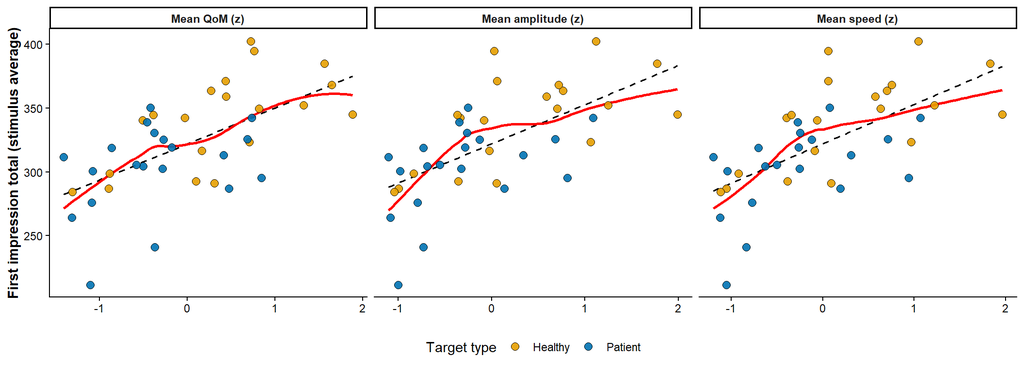

```r
# Stimulus-level dataset with each raw metric
q_scores     <- prepare_questionnaire_scores(data_imp)
p_metrics    <- build_participant_metrics(movement_features)
stim_metrics <- q_scores |>
  dplyr::group_by(participant_id, Type) |>
  dplyr::summarise(
    FirstImpression_total = mean(FirstImpression_total, na.rm = TRUE),
    .groups = "drop"
  ) |>
  dplyr::inner_join(p_metrics, by = "participant_id")

metric_labels <- c(
  mean_QoM           = "Mean QoM (z)",
  mean_amplitude_sum = "Mean amplitude (z)",
  mean_mean_speed    = "Mean speed (z)"
)

stim_long <- stim_metrics |>
  tidyr::pivot_longer(
    cols      = names(metric_labels),
    names_to  = "metric",
    values_to = "value"
  ) |>
  dplyr::mutate(metric = factor(metric, levels = names(metric_labels),
                                labels = metric_labels))

fig_per_metric <- ggplot(stim_long,
                         aes(x = value, y = FirstImpression_total)) +
  geom_smooth(method = "lm",    se = FALSE, linetype = "dashed",
              color = "black", linewidth = 0.7) +
  geom_smooth(method = "loess", se = FALSE, color = "red",
              linewidth = 0.9, alpha = 0.7) +
  geom_point(aes(fill = Type), shape = 21, size = 2.8,
             color = "black", stroke = 0.4, alpha = 0.9) +
  scale_fill_manual(values = c("Healthy" = "#E69F00", "Patient" = "#0072B2")) +
  facet_wrap(~ metric, scales = "free_x") +
  labs(x = NULL,
       y = "First impression total (stimulus average)",
       fill = "Target type") +
  theme_classic(base_size = 11) +
  theme(legend.position = "bottom",
        strip.text = element_text(face = "bold"),
        axis.title = element_text(face = "bold"))

ggsave("../results/figures/scatter_each_metric_impression.png",
       fig_per_metric, width = 11, height = 4, dpi = 150)

fig_per_metric
```

The three scatterplots look nearly identical in shape and strength. This confirms that the three metrics capture the same underlying dimension and can safely be combined into one composite score.

## 2. Composite score against First impression (regression)

We combine the three z-scored metrics into `movement_global` by taking their mean, then fit a simple linear regression at the stimulus level (n = 40): **FirstImpression_total ~ movement_global**.

```r
reg_res <- build_metric_impression_regression(data_imp, movement_features)

# Save the two views of the regression
write_csv(reg_res, "../results/tables/metric_impression_regression.csv")

# Extract the model-level stats for the plot annotation
reg_r2      <- reg_res$R2[1]
reg_f       <- reg_res$F_stat[1]
reg_df_num  <- reg_res$df_num[1]
reg_df_den  <- reg_res$df_den[1]
reg_p       <- reg_res$p[reg_res$Predictor == "Movement composite (+1 SD)"]
reg_slope   <- reg_res$B[reg_res$Predictor == "Movement composite (+1 SD)"]

# Build the APA table (coefficients only; F/R² go in the note)
reg_tab <- dplyr::select(reg_res, Predictor, B, SE, t, p)

rempsyc::nice_table(
  reg_tab,
  title = c("Table 3",
            "Linear regression: FirstImpression ~ Movement composite (n = 40 stimuli)"),
  note  = c(sprintf("Model: R² = %.3f, F(%d, %d) = %.2f, p %s.",
                    reg_r2, reg_df_num, reg_df_den, reg_f,
                    ifelse(reg_p < .001, "< .001",
                           sprintf("= %.3f", reg_p))),
            "* p < .05, ** p < .01, *** p < .001")
)
```

| Table 3 Linear regression: FirstImpression ~ Movement composite (n = 40 stimuli) Predictor | Table 3 Linear regression: FirstImpression ~ Movement composite (n = 40 stimuli) b* | Table 3 Linear regression: FirstImpression ~ Movement composite (n = 40 stimuli) SE | Table 3 Linear regression: FirstImpression ~ Movement composite (n = 40 stimuli) t | Table 3 Linear regression: FirstImpression ~ Movement composite (n = 40 stimuli) p |
| --- | --- | --- | --- | --- |
| Intercept | 321.96 | 4.90 | 65.68 | < .001*** |
| Movement composite (+1 SD) | 30.87 | 6.07 | 5.09 | < .001*** |

Note. Model: R² = 0.405, F(1, 38) = 25.90, p < .001.  
* p < .05, ** p < .01, *** p < .001

### Scatter plot with regression line

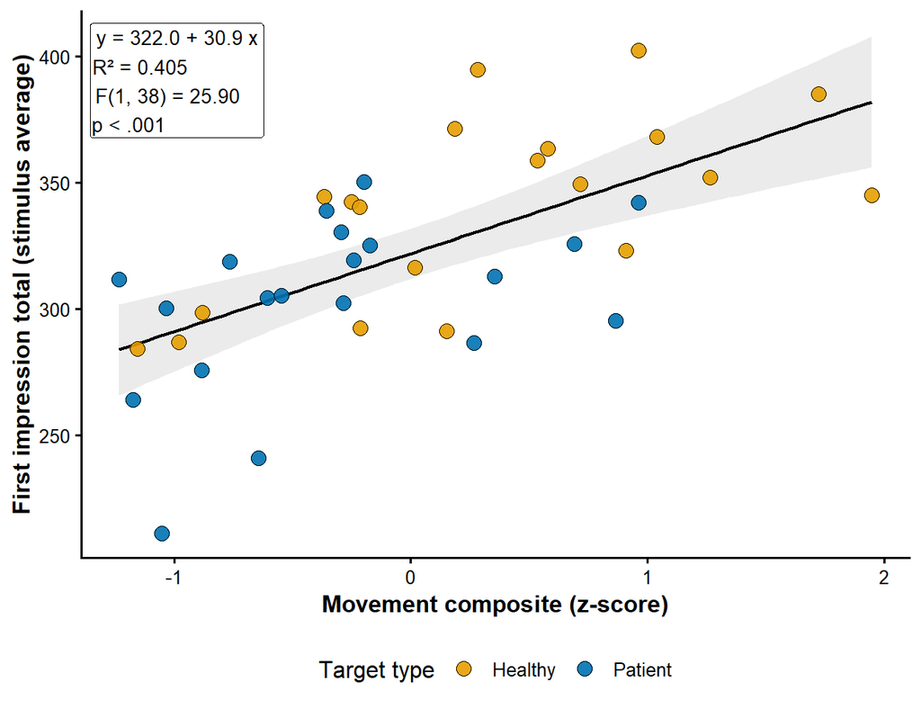

```r
composite  <- build_participant_composite(movement_features)
stim_comp  <- q_scores |>
  dplyr::group_by(participant_id, Type) |>
  dplyr::summarise(
    FirstImpression_total = mean(FirstImpression_total, na.rm = TRUE),
    .groups = "drop"
  ) |>
  dplyr::inner_join(composite, by = "participant_id")

# Build the in-plot annotation string
p_str <- ifelse(reg_p < .001, "< .001", sprintf("= %.3f", reg_p))
annot <- sprintf(
  "y = %.1f + %.1f x\nR² = %.3f\nF(%d, %d) = %.2f\np %s",
  reg_res$B[reg_res$Predictor == "Intercept"],
  reg_slope, reg_r2, reg_df_num, reg_df_den, reg_f, p_str
)

fig_composite <- ggplot(stim_comp,
                        aes(x = movement_global, y = FirstImpression_total)) +
  geom_smooth(method = "lm", se = TRUE, color = "black",
              fill = "grey80", linewidth = 0.8) +
  geom_point(aes(fill = Type), shape = 21, size = 3.5,
             color = "black", stroke = 0.4, alpha = 0.9) +
  scale_fill_manual(values = c("Healthy" = "#E69F00", "Patient" = "#0072B2")) +
  annotate("label", x = -Inf, y = Inf, label = annot,
           hjust = -0.05, vjust = 1.1, size = 3.6,
           label.size = 0.3, fill = "white") +
  labs(x = "Movement composite (z-score)",
       y = "First impression total (stimulus average)",
       fill = "Target type") +
  theme_classic(base_size = 12) +
  theme(legend.position = "bottom",
        axis.title = element_text(face = "bold"))

ggsave("../results/figures/scatter_movement_impression.png",
       fig_composite, width = 6.5, height = 5, dpi = 150)

fig_composite
```

## 3. Mixed model: FirstImpression ~ Type + Movement composite

Observers never knew whether the person they rated was Healthy or Patient. So the `Type` coefficient does **not** measure a conscious bias — it measures whatever differs in the point-light display between groups that observers pick up implicitly, **beyond** what the movement composite already captures.

Reading the table:

- **Patient vs Healthy** (B): mean difference in First-impression score, in raw points, after controlling for movement and presentation order. Healthy is the reference, so a negative B means “Patient lower than Healthy”. Here Healthy is coded as the reference.
- **Movement composite (+1 SD)** (B): how many First-impression points are gained for each additional standard deviation of movement.
- **Presentation order** (B): effect of the video’s rank in the sequence (1 to 10).

```r
model_out <- fit_metric_impression_model(data_imp, movement_features)

write_csv(model_out$coefficients,
          "../results/tables/metric_impression_model.csv")
write_csv(model_out$fit,
          "../results/tables/metric_impression_model_fit.csv")

rempsyc::nice_table(
  model_out$coefficients,
  title = c("Table 4",
            "Linear mixed model: FirstImpression ~ Type + Movement composite"),
  note  = c("Random intercepts for observers (CASE) and videos (video_id). B for 'Patient vs Healthy' reads directly as the mean difference (Patient minus Healthy) controlling for movement and presentation order.",
            "* p < .05, ** p < .01, *** p < .001")
)
```

| Table 4 Linear mixed model: FirstImpression ~ Type + Movement composite Predictor | Table 4 Linear mixed model: FirstImpression ~ Type + Movement composite b* | Table 4 Linear mixed model: FirstImpression ~ Type + Movement composite SE | Table 4 Linear mixed model: FirstImpression ~ Type + Movement composite t |
| --- | --- | --- | --- |
| Patient vs Healthy | -21.06 | 9.16 | -2.30 |
| Movement composite (+1 SD) | 25.78 | 5.73 | 4.50 |
| Presentation order | 0.28 | 0.83 | 0.34 |

Note. Random intercepts for observers (CASE) and videos (video_id). B for 'Patient vs Healthy' reads directly as the mean difference (Patient minus Healthy) controlling for movement and presentation order.  
* p < .05, ** p < .01, *** p < .001

```r
rempsyc::nice_table(
  model_out$fit,
  title = c("Table 4 (fit)",
            "Model fit indices"),
  note  = "Marginal R² = variance explained by the fixed effects alone. Conditional R² = variance explained by fixed + random effects combined. Nakagawa & Schielzeth (2013)."
)
```

| Table 4 (fit) Model fit indices Index | Table 4 (fit) Model fit indices Value |
| --- | --- |
| Marginal R² | 0.092 |
| Conditional R² | 0.348 |
| N observations | 910 |

Note. Marginal R² = variance explained by the fixed effects alone. Conditional R² = variance explained by fixed + random effects combined. Nakagawa & Schielzeth (2013).